# C08

Previous:Lecture 7 C Function Next: Lecture 9 Algorithm Design

Lecture 8 Loop structure(indefinite loop)

#### CSCI218 Engineering Programming (by Kebin Xu)

1. Review L06: Counted(definate) loop (for loop)
2. while loop
   - infinite loop
   - sentinel loop
3. do while loop
4. Loop and a half
5. Random number generator
6. Examples

# 1. Definite loop( for loop)

in Lecture 6, we learned for loop.

- The for loop is a **definite loop or counted loop**, meaning that the number of iterations is determined when the loop starts.
- The for loop is most often used when iterating through a sequence of a ·pre-defined· length.

[figure not shown]

- for(i = 0; i < n; i++) -> n iterations
- for (i = 0; i < n; i += 2) -> n/2 iterations
- for (i = 0; text[i] != '\0'; i++) -> strlen(text) iterations

```c
//Ex1-Q1: calculate the sum of numbers the user enters
//using for loop, user has to enter how many numbers n he will enter first
#include <stdio.h>
int main(){
    int n, i;
    float x, total = 0.0;
    printf("Enter how many numbers: ");
    scanf("%d", &n);

    for (i = 0;i< n;i++){
        printf("\nEnter a number:");
        scanf("%f", &x);
        total += x;
    }
    printf("\nThe sum of %d numbers the user enters is %.2f", n, total);

}
```

```c
//Ex1-Q2: calculate the sum of numbers the user enters
//the program let the user decide when to stop enter the number
#include <stdio.h>
#include <string.h>
#include <ctype.h>
int main(){
    int n;
    float x, total = 0.0;
    char userInput;
    //initialization
    n = 0;
    userInput = 'Y';

    while(toupper(userInput)=='Y'){ //allow user to enter 'y' as the same as 'Y'
    //while (userInput == 'Y') {
        printf("\nEnter a number:");
        scanf("%f", &x);
        printf("\nType Y to continue, any other to quit: ");
        scanf(" %c", &userInput); // please be noted the space before %c
        total += x;
        n ++;

    }

    printf("\nThe sum of %d numbers the user enters is %.2f", n, total);
    return 0;

}
```

### note:**" %c"**

- Notice the space before the %c in the scanf(**" %c"**, &userChar) statement above. The space causes scanf to first read and discard any whitespace characters, including spaces (' '), tabs ('\t'), and newline ('\n') characters, in the user input before reading and storing the character indicated by the %c format specifier.
- Above, if the user presses key '5' followed by pressing enter, the system sends two characters to the program: '5' and then a newline character '\n' (some systems send both '\n' plus '\r'). If the statement was instead scanf("%c", &userChar) without the space before %c, the scanf would read the '\n' into userChar and quit the program.

back to top

# 2. While loop

## 2.1 while loop syntax

- A while loop is a program construct that repeatedly executes a list of sub-statements (known as the loop body) while the loop's expression evaluates to true.

[figure not shown]

```
initial condition
while (test) { // Loop test
    // Loop body: Executes if test evaluated to true
    // condition update
    // After body, execution jumps back to the "while"
}
// Statements that execute after the test evaluates to false
```

- Each execution of the loop body is called an iteration.
- Once entering the loop body, execution continues to the body's end, even if the test would become false midway through.

### 2.2 while loop is a pre-test loop

- In the flow chart,the condition is always tested at the top of the loop, before the loop body is executed. This kind of structure is called **pre-test loop**

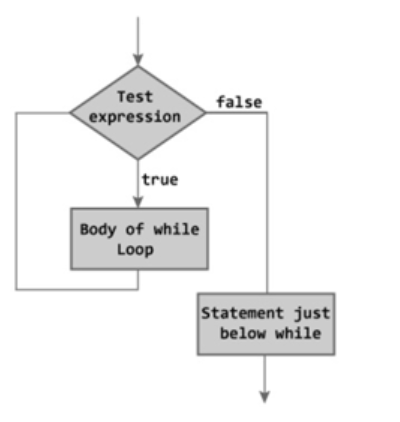

## 2.2 while loop vs for loop

- for loop is definite loop, counted loop, while loop is indefinite loop
- For some application, a while loop can be equivalent to a for loop
- For example: print number from 0 to 3(inclusive)

```c
//a for loop that print from 0 to 3(inclusive),
#include <stdio.h>
int main(){
    int i;
    for (i = 0; i <= 3; i ++){
        printf("%d ", i);

    }
    printf("\nDone!");
    return 0 ;
}
```

```
0 1 2 3
Done!
```

```c
// a while loop that print from 0 to 3(inclusive),
#include <stdio.h>
int main(){
    int i = 0;           //initialization loop variable
    while (i <= 3){      //check condition
        printf("%d ",i); //body
        i ++;          //update the loop variable, if it is not updated, the loop becomes infinite loop
    }
    printf("\nDone!");
    return 0;
}
```

## 2.3 common error (infinite loop)

what will happen with thie following code?

```c
#include <stdio.h>
int main(){
    int i = 0;           //initialization loop variable
    while (i <= 3){      //check condition
        printf("%d ",i); //body
        //i += 1;
    }
    printf("\nDone!");
    return 0;
}
```

- This is an example of `infinite loop`
- What should you do if you’re caught in an infinite loop?
  - First, try pressing control-c
  - If that doesn’t work, try control-alt-delete
  - If that doesn’t work, push the reset button!

```c
//another infinite loop example
#include<stdio.h>
void main ()
{
    int x = 10, y = 2;
    while(x+y-1)
    {
        printf("%d %d",x--,y--);
    }
}
```

```c
//Another infinite loop example
while(1){
//statement
}
```

```c
// wrong syntax
while(){
//statement
}
```

back to top

## 2.4 Sentinel loop

- From some application, it is hard to figure out all the situation that makes the condition remains true, but easier to figure out the `stop condition`(also called loop boundary or **sentinel**).
  - For example:
    - kepp asking user to enter 'y' or 'Y' to continue (interactive pattern)
    - keep asking user to enter a number until user enters -1(**stop condition: -1**);
    - keep asking user to enter password until user enter a valid password ( **stop condition: rules to make a password valid** );
      - It is easy for us to formulate the `valid` password (follow certain rules)
- all above problems follow the similar pattern using **while** loop

  ```
  while not <stop condition >:
             <loop body>
  ```

```c
//Ex1-Q2: calculate the sum of numbers the user enters
//the program let the user decide when to stop enter the number
#include <stdio.h>
#include <string.h>
#include <ctype.h>
int main(){
    int counter;
    float x, total = 0.0;
    counter = 0;
    char userInput = 'y'; //initialize loop variable

    while(toupper(userInput)=='Y'){
    //while (userInput == 'y') {
        printf("\nEnter a number:");
        scanf("%f", &x);
        printf("\nType Y to continue, any other to quit: ");
        scanf(" %c", &userInput); // please be noted the space before %c
        total += x;
        counter ++;

    }

    printf("\nThe sum of %d numbers the user enters is %.2f", counter, total);
    return 0;

}
```

### 2.4.2 sentinel loop pattern

- in some application, we can use the data variable as the loop variable

```
get the first data item  //priming read
while item is not the sentinel:
    process the item
    get the next data item
```

- The first item is retrieved before the loop starts. This is sometimes called the `priming read`, since it gets the process started.
- If the first item is the sentinel, the loop terminates and no data is processed.
- Otherwise, the item is processed and the next one is read.

```c
//Ex2-Q1: calculate the sum of all numbers except -999999 the user enters
//the program let the user decide when to stop asking user to enter more number once user enter -999999
#include <stdio.h>
int main(){
    int i, n;
    float x, total = 0.0;
    n = 0;
    printf("\nEnter a number untill you enter -999999 to stop:");
    scanf("%f", &x);
    while(x != -999999){
        total += x;
        n ++;
        printf("\nEnter a number:");
        scanf("%f", &x);

    }

    printf("\nThe sum of %d numbers the user enters is %.2f", n, total);

}
```

Notes:

- how about the prime reading is the sentinel, so that while loop statement never get processed?
- prime reading also introduce duplicate code
- see the following example

### Good input

Write a function called goodInput() that asks for a number to be input. The function should ask user to enter a good input as any number that is -1, inclusively in the range 1 to 10, or is greater than 50. If the input is outside of these, ask for input again until a proper value is entered. The function should return the “good input” received by the user.

```c
#include <stdio.h>
//solution1: priming read (duplicate code)
float goodInput1(){
    float num;
    printf("Please enter a number (-1, inclusively in the range 1 to 10, or is greater than 50)");
    scanf("%f", &num); //priming read
    //stop: num == -1 || num >= 1 and num <= 10 || num>50
    //while: not stop !(num == -1 || (num >= 1 and num <= 10) || num>50)
    while(num!= -1 &&(num < 1 || num > 10) && num <=50){
        printf("Enter a number ( -1,  or inclusively in the range 1 to 10, or is greater than 50):");
        scanf("%f", &num);
    }
    return num;
}
//solution2: invalid initialization to enter the loop
float goodInput2(){
    float num = 20;
    //stop: num == -1 || num >= 1 and num <= 10 || num>50
    //while: not stop !(num == -1 || (num >= 1 and num <= 10) || num>50)
    while(num!= -1 &&(num < 1 || num > 10) && num <=50){
        printf("Enter a number ( -1,  or inclusively in the range 1 to 10, or is greater than 50):");
        scanf("%f", &num);
    }
    return num;

}

int main(){
    float x = goodInput();
    printf("The good input the user enters is %.1f", x);

    return 0;
}
```

back to top

- if we want the loop statement is excuted at least once, then we will use another loop pattern: do-while

# 3. do-while loop

```c
// a while loop that print from 0 to 3(inclusive),
#include <stdio.h>
int main(){
    int i = 0;           //initialization loop variable
    while (i <= 3){      //check condition
        printf("%d ",i); //body
        i ++;          //update the loop variable, if it is not updated, the loop becomes infinite loop
    }
    printf("\nDone!");
    return 0;
}
```

```
0 1 2 3
Done!
```

```c
// a do-while loop that print from 0 to 3(inclusive),
#include <stdio.h>
int main(){
    int i = 0;           //initialization loop variable
    do {
        printf("%d ",i); //body
        i ++;          //update the loop variable, if it is not updated, the loop becomes infinite loop
    } while (i <= 3)  ;    //check condition
    printf("\nDone!");
    return 0;
}
```

```
0 1 2 3
Done!
```

```c
#include <stdio.h>
//solution3: do while
float goodInput3(){
    float num;
    do {
        printf("Enter a number ( -1,  or inclusively in the range 1 to 10, or is greater than 50):");
        scanf("%f", &num);
    } while(num!= -1 &&(num < 1 || num > 10) && num <=50);
    return num;
}

int main(){
    float x = goodInput3();
    printf("The good input the user enters is %.1f", x);

    return 0;
}
```

back to top

# 4. Loop and a half

- loop exit by checking the sentinel is True and use keyword `break` in the middle of the loop body, so called a loop and a half.
- The loop and a half is an elegant way to avoid priming read in a sentinel loop by using

  ```
  while True:
    < get the data >
    if < stop condition >
        break;
    else{ #optional
        < process the data or print message > }
  ```

```c
// counting user's positive number input until user enter a negative number
#include <stdio.h>
int main(){

    int num,count;
    //initialization
    count = 0;
    while(1){
        scanf("%d", &num);
        if(num < 0)
            break;
        else count++;
    }

    printf("The  user enters %d positive numbers", count);

    return 0;
}
```

```c
#include <stdio.h>
//solution4: loop and a half
float goodInput4(){
    float num;
    while(1){
        printf("Enter a number ( -1,  or inclusively in the range 1 to 10, or is greater than 50):");
        scanf("%f", &num);
        if(num == 1 || (num >=1 && num <= 10) || num > 50)
            return num;
    }

}

int main(){
    float x = goodInput4();
    printf("The good input the user enters is %.1f", x);

    return 0;
}
```

back to top

# 5 Random number generator

see [zyBook 1.11 Modulo example](https://learn.zybooks.com/zybook/COFCCSCI218XuFall2022/chapter/2/section/11?content_resource_id=61936237) , and [zyBook2.19](https://learn.zybooks.com/zybook/COFCCSCI218XuFall2022/chapter/2/section/19)

- The C library function int **rand(void)** returns a pseudo-random number in the range of 0 to RAND_MAX.
- RAND_MAX is a constant whose default value may vary between implementations but it is granted to be at least 32767.
- Usually, a programmer wants a random integer restricted to a specific number of possible values. The modulo operator % can be used. Ex: integer % 10 has 10 possible remainders: 0, 1, 2, ..., 8, 9.
- Specific ranges: [START, END] using rand() % (END-START +1 ) + START

```c
#include <stdio.h>
#include <stdlib.h>   // Enables use of rand()

int main(void) {
    int i, n = 10;
    printf("RAND_MAX: %d\n", RAND_MAX);
    srand(4); //set the seed as 4
    printf("Generate %d random number between [0, 19]\n", n);
    for (i = 0; i< n; i++){
        int num = rand();
        printf("rand() = %d\t rand()%%2 = %d \n ", num, num %20);
    }

    int start = 10, end = 15;
    printf("\nGenerate  %d random number between [%d, %d]\n", n, start, end);
    for (i = 0; i< n; i++){
        printf("%d ", rand()%(end - start + 1) + start);
    }

   return 0;
}
```

```
RAND_MAX: 2147483647
Generate 10 random number between [0, 19]
rand() = 67228	 rand()%2 = 8
 rand() = 1129900996	 rand()%2 = 16
 rand() = 48149351	 rand()%2 = 11
 rand() = 1792290985	 rand()%2 = 5
 rand() = 281468426	 rand()%2 = 6
 rand() = 1880845088	 rand()%2 = 8
 rand() = 404110176	 rand()%2 = 16
 rand() = 1536436218	 rand()%2 = 18
 rand() = 1540144398	 rand()%2 = 18
 rand() = 1586499895	 rand()%2 = 15

Generate  10 random number between [10, 15]
15 10 13 12 10 10 12 14 13 14
```

```c
#include <stdio.h>
#include <stdlib.h>   // Enables use of rand()
#include <time.h>     // Enables use of time()
int main(void) {
    int i, n = 10;

    srand((int)time(0)); // Unique seed every time you run this program
    printf("Generate %d random number between [0, 19]\n", n);
    for (i = 0; i< n; i++){
        printf("%d ", rand()%20);
    }

    int start = 10, end = 15;
    printf("\nGenerate  %d random number between [%d, %d]\n", n, start, end);
    for (i = 0; i< n; i++){
        printf("%d ", rand()%(end - start + 1) + start);
    }

   return 0;
}
```

```
Generate 10 random number between [0, 19]
13 18 6 7 6 13 4 2 10 14
Generate  10 random number between [10, 15]
13 12 14 12 14 12 12 11 14 12
```

```c
“+”, “*”, “%”, “/”, “>”, “<” , “==”
```

```c
#include <stdio.h>
#include <stdlib.h>   // Enables use of rand()
#include <time.h>     // Enables use of time()
#include <string.h>

int main(void) {
    int i, n = 10;

    srand((int)time(0)); // random seed every time you run this program
    printf("Generate %d random number between [0, 19]\n", n);
    for (i = 0; i< n; i++){
        printf("%d ", rand()%20);
    }

    char ops[][3] = {"+", "-", "/", "*", "<", "==", ">"};
    int index = rand()%7;
    char op[3];
    strcpy(op, ops[index]);
    printf("\nindex: %s ", op);

    char expr[20];
    sprintf(expr, "%d %s %d ", rand()%20, ops[index], rand()%20);
    printf("\n %s", expr);
   return 0;
}
```

```
Generate 10 random number between [0, 19]
0 7 4 10 0 18 16 3 13 13
index: +
 15 + 10
```

back to top

# 5. More Examples

### 5.1 Example:Conversation program.

see [zy_ch4.3Example](https://learn.zybooks.com/zybook/COFCCSCI218XuFall2022/chapter/4/section/3) Below is a program that has a "conversation" with the user, asking the user to type something and then (randomly) printing one of four possible responses until the user enters "Goodbye".

```c
#include <stdio.h>
#include <string.h>

/* Program that has a conversation with the user.
   Uses a if-else statements and a random number (sort of)
   to mix up the program's responses. */

int main(void) {
  const int TEXT_LIMIT = 1000;    // Size limit for user input
  char userText[TEXT_LIMIT];      // User input
  int rand0_3;                    // Random number 0 - 3

  printf("Tell me something about yourself.\n");
  printf("You can type \"Goodbye\" at anytime to quit.\n\n> ");

  fgets(userText, TEXT_LIMIT, stdin);    // Reads a full line of text
  userText[strlen(userText) - 1] = '\0'; // Replaces the newline character

  while (strcmp(userText, "Goodbye") != 0) { //"Goodbye" is the sentinel
    rand0_3 = strlen(userText) % 4;      // "Random" num. %4 ensures 0-3

    if (rand0_3 == 0) {
      printf("\nPlease explain further.\n\n> ");
    }
    else if (rand0_3 == 1) {
      printf("\nWhy do you say: \"%s\"?\n\n> ", userText);
    }
    else if (rand0_3 == 2) {
      printf("\nI don't think that's right.\n\n> ");
    }
    else if (rand0_3 == 3) {
      printf("\nWhat else can you share?\n\n> ");
    }
    else {
      printf("\nUh-oh, something went wrong. Try again.\n\n");
    }

    fgets(userText, TEXT_LIMIT, stdin); //get the data
    userText[strlen(userText)-1] = '\0';
  }

  printf("\nIt was nice talking with you. Goodbye.\n\n");

  return 0;
}
```

- The loop checks whether userText is "Goodbye"; if not, the loop body executes. The loop body generates a "random" number between 0 and 3, by getting the length of the user's text (which is sort of random) and mod'ing by 4. The loop body then prints one of four messages, using an if-else statement.
- If you haven't covered fgets, just know that fgets reads an entire line of text. In contrast, scanf would just read a word (stopping when reaching a space).

## 5.2 valid password

write a program that keeps asking user to enter password untill user enter a valid password. `Valid` password should satisfy:

- starts with uppercase letter OR
- end with '*'

**Requirement**: cannot have `not` in while conditon

### such questions have a pattern

1. Get initial input
2. While input is not valid: # not stop
   1. Display message to user
   2. Get input again

```c
pwd = "Fsddddsdf"
// condition 1 : starts with uppercase letter
pwd[0] >= 'A' && pwd[0] <= 'Z'
```

```
True
```

```c
// condition 2 :
pwd[strlen(pwd)-1] == '*' //end with '*'
```

```
False
```

```c
#stop condition //valid rule
(pwd[0] >= 'A' && pwd[0] <= 'Z' ) || pwd[strlen(pwd)-1] == '*'
```

```
True
```

```c
//Solution1 while(not stop) + priming read
#include <stdio.h>
#include <string.h>

// not stop ->!((pwd[0] >= 'A' && pwd[0] <= 'Z' ) || pwd[strlen(pwd)-1] == '*' )
// apply DeMorgan's Law
// (pwd[0] < 'A' || pwd[0] > 'Z') && (pwd[strlen(pwd)-1] != '*')
int main(){
    char pwd[20]; //make up a invalid one to enter the loop
    printf("\nEnter passward (starts with uppercase letter OR end with *):");
    scanf("%s", pwd);
    while((pwd[0] < 'A' || pwd[0] > 'Z') && (pwd[strlen(pwd)-1] != '*')){

        printf("\nEnter passward (starts with uppercase letter OR end with *):");
        scanf("%s", pwd);

    }
    printf("\nThe valid password the user enters is %s", pwd);
    return 0;

}
```

```c
//Solution1b while(not stop) + priming read using isupper() to test a uppercase
#include <stdio.h>
#include <string.h>
#include <ctype.h>

// not stop ->!(isupper(pwd[0]) || pwd[strlen(pwd)-1] == '*' )
// apply DeMorgan's Law
// !isupper(pwd[0]) && (pwd[strlen(pwd)-1] != '*')
int main(){
    char pwd[20]; //make up a invalid one to enter the loop
    printf("\nEnter passward (starts with uppercase letter OR end with *):");
    scanf("%s", pwd);
    while(!isupper(pwd[0]) && (pwd[strlen(pwd)-1] != '*')){

        printf("\nEnter passward (starts with uppercase letter OR end with *):");
        scanf("%s", pwd);

    }
    printf("\nThe valid password the user enters is %s", pwd);
    return 0;

}
```

```c
//Solution2 while(not stop) + initialization by hard assignning an invalid value
#include <stdio.h>
#include <string.h>
#include <ctype.h>

int main(){
    char pwd[20]= "s"; //make up an invalid one to enter the loop
    while(!isupper(pwd[0]) && (pwd[strlen(pwd)-1] != '*')){

        printf("\nEnter passward (starts with uppercase letter OR end with *):");
        scanf("%s", pwd);

    }
    printf("\nThe valid password the user enters is %s", pwd);
    return 0;

}
```

```c
//Solution3.  do-while
#include <stdio.h>
#include <string.h>
#include <ctype.h>

int main(){
    char pwd[20];
    do {
        printf("\nEnter passward (starts with uppercase letter OR end with *):");
        scanf("%s", pwd);
    }
    while(!isupper(pwd[0]) && (pwd[strlen(pwd)-1] != '*'));

    printf("\nThe valid password the user enters is %s", pwd);
    return 0;

}
```

```c
//Solution4  loop and a halfo
#include <stdio.h>
#include <string.h>
#include <ctype.h>

int main(){
    char pwd[20];
    while(1){
        printf("\nEnter a valid passward(starts with uppercase letter or ends with \"*\"");
        scanf("%s", pwd);
        if(isupper(pwd[0]) || pwd[strlen(pwd)-1] == '*' ){
            break;
        }
        else{ //optional
            printf("Not valid, must starts with uppercase letter or ends with \"*\"");
        }
    }

    printf("\nThe valid password the user enters is %s", pwd);
    return 0;

}
```